# Pricing Financial Derivatives HW2

Akash Yadav, Lucas Costa Santos

2023-03-20

```r
rm(list = ls())
library(pracma)
library(stats)
pacman::p_load("tidyquant", "tidyverse", "ggplot2", "writexl", "plotly", "readxl")
Sys.setenv(RETICULATE_PYTHON = "/usr/local/bin/python3")
RETICULATE_PYTHON="/usr/local/bin/python3"
library(reticulate)
```

# Exercise 1

1. To compute the implied volatility, we first write down the time-dependent volatility as a function.

```r
sig_t <- function(t){
  a <- ((0.5-t < 1/12)*(0.17) + (1/12 <= 0.5-t & 0.5-t < 3/12)*(0.15) + (3/12 <= 0.5-t & 0.5-t < 5/12)*(0.13) + (0.5-t >= 5/12)*(0.12))
  ifelse(t>0.5, 0, a)
}
```

Recall, implied-volatility is given by

$$\bar{\sigma}_{t, T} = \sqrt{\frac{1}{T-t} \int_t^T \sigma_s^2 ds}$$
where $\sigma_s$ is the time dependent volatility.

```r
sig_sq_t <- function(t){
  a <- ((0.5-t < 1/12)*(0.17) + (1/12 <= 0.5-t & 0.5-t < 3/12)*(0.15) + (3/12 <= 0.5-t & 0.5-t < 5/12)*(0.13) + (0.5-t >= 5/12)*(0.12))
  ifelse(t>0.5, 0, a*a)
}
```

Since this is a computationally tractable integral, we can write a function to find implied volatility without using integration function from packages. These functions are generally slow and give approximate answers.

```r
imp_sig <- function(t){
  comp <- ((0.5-t < 1/12)*(0.17) + (1/12 <= 0.5-t & 0.5-t < 3/12)*(sqrt((1/(0.5-t))*((0.15*0.15*(5/12 - t)) + (0.17*0.17*(1/12))))) + (3/12 <= 0.5-t & 0.5-t < 5/12)*(sqrt((1/(0.5-t))*((0.13*0.13*(0.25-t)) + (0.15*0.15*(1/6)) + (0.17*0.17*(1/12))))) + (0.5-t >= 5/12)*(sqrt((1/(0.5-t))*((0.12*0.12*((1/12)-t)) + ((0.15*0.15 + 0.13*0.13)*(1/6)) + (0.17*0.17*(1/12))))))
  ifelse(t>0.5, 0, comp)
}
```

Now, we can plot the implied volatility $\bar{\sigma}_{t, T}$.

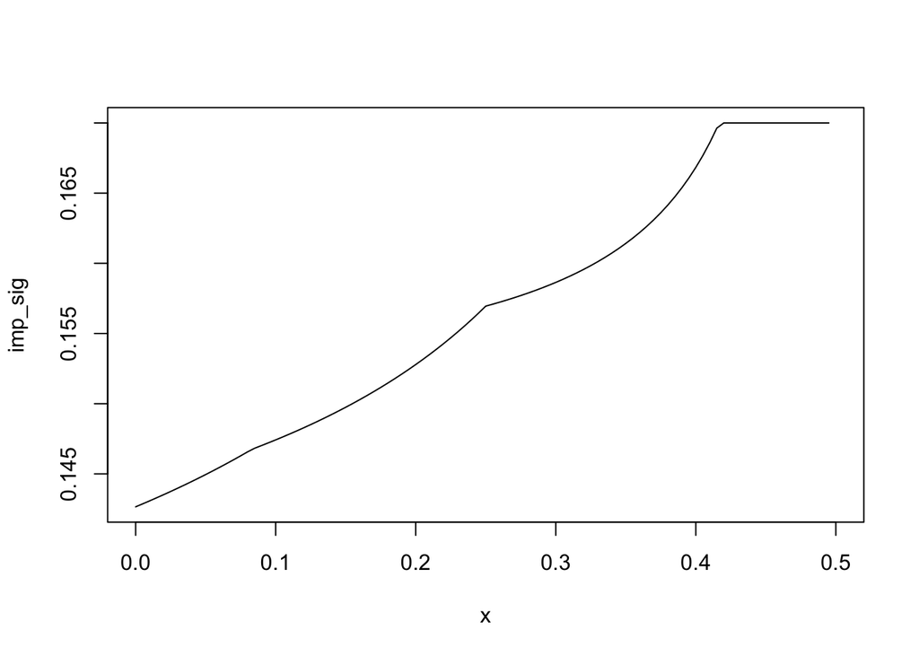

```r
plot(imp_sig, xlim = c(0, 0.5))
```

```r
N <- 1000        # fixing N
t <- seq(0, 0.5, by = 0.5/(N-1))
imp_vol_vec <- imp_sig(t)
```

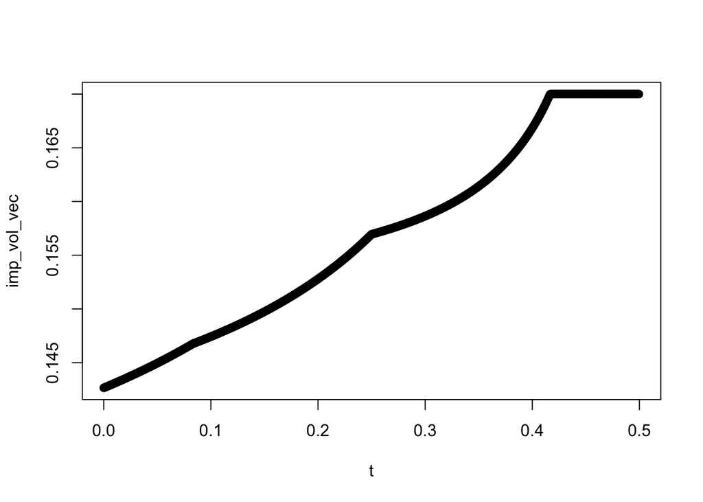

```r
plot(t, imp_vol_vec, xlim = c(0, 0.5))
```

2. Next, we fix values for asset price at time $t=0$, interest-rate, $r$, number of time-steps $N$ and simulate several trajectories by running a for-loop through the set seed values.

Recall, Black-Scholes PDE is given by

$$dS_t = S_t(\sigma_t dB_t + rdt)$$
Discretizing this equation, we have

$$S_{j \Delta t} = S_{(j-1) \Delta t} + S_{(j-1) \Delta t}\big(
\sigma_{(j-1) \Delta t} \sqrt{\Delta t}\ \mathcal{N} (0,1) + r \Delta t
\big)$$
since $B_t$ is standard Normal with variance $\Delta t$.

Also, price of European call option struck at $K$ is given by

$$C_t = S_t N(d_{1,t}) - Ke^{-r(T-t)}N(d_{2,t})$$
where $N$ is calculated by the *pnorm* function and $d_{1,t}$ and $d_{2,t}$ are as defined in the lecture.

```r
df_S_C <- data.frame(matrix (ncol = 0, nrow = N)) # empty dataframe to store values
for(s in c(123:126)){
  set.seed(s)
  N <- 1000 # fixed
  X <- rnorm(N, mean = 0, sd = 1)
  r <- 0.1 # fixed
  S <- rep(0, N)
  C <- rep(0, N)
  S[1] = 1000
  K = 200
  d1 <- rep(0, N)
  d2 <- rep(0,N)
  d1[1] <- (log(S[1]/K) + (r + 0.5*imp_vol_vec[1]*imp_vol_vec[1])*(0.5))/imp_vol_vec[1]
  d2[1] <- (log(S[1]/K) + (r - 0.5*imp_vol_vec[1]*imp_vol_vec[1])*(0.5))/imp_vol_vec[1]
  C[1] = S[1]*pnorm(d1[1]) - K*exp(-r*0.5)*pnorm(d2[1])

  # S_0 -> S_{j \Delta t}
  # \sigma <- implied volatility
  # T <- T - j \Delta t

  for (i in 2:167){ # time-steps until 1 month
    S[i] = S[i-1] + S[i-1]*((0.12*sqrt(0.5/N)*X[i-1]) + r*(0.5/N))
    d1[i] = (log(S[i]/K) + (r + 0.5*imp_vol_vec[i]*imp_vol_vec[i])*(0.5))/imp_vol_vec[i]
    d2[i] = (log(S[i]/K) + (r - 0.5*imp_vol_vec[i]*imp_vol_vec[i])*(0.5))/imp_vol_vec[i]
    C[i] = S[i]*pnorm(d1[i]) - K*exp(-r*0.5)*pnorm(d2[i])
  }
  for (i in 168:500){ # time-steps 1 month - 3 months
    S[i] = S[i-1] + S[i-1]*((0.13*sqrt(0.5/N)*X[i-1]) + r*(0.5/N))
    d1[i] = (log(S[i]/K) + (r + 0.5*imp_vol_vec[i]*imp_vol_vec[i])*(0.5))/imp_vol_vec[i]
    d2[i] = (log(S[i]/K) + (r - 0.5*imp_vol_vec[i]*imp_vol_vec[i])*(0.5))/imp_vol_vec[i]
    C[i] = S[i]*pnorm(d1[i]) - K*exp(-r*0.5)*pnorm(d2[i])
  }
  for (i in 501:834){ # time-steps 3 months - 5 months
    S[i] = S[i-1] + S[i-1]*((0.15*sqrt(0.5/N)*X[i-1]) + r*(0.5/N))
    d1[i] = (log(S[i]/K) + (r + 0.5*imp_vol_vec[i]*imp_vol_vec[i])*(0.5))/imp_vol_vec[i]
    d2[i] = (log(S[i]/K) + (r - 0.5*imp_vol_vec[i]*imp_vol_vec[i])*(0.5))/imp_vol_vec[i]
    C[i] = S[i]*pnorm(d1[i]) - K*exp(-r*0.5)*pnorm(d2[i])
  }
  for (i in 835:1000){ # time-steps 5 months - 6 months (maturity)
    S[i] = S[i-1] + S[i-1]*((0.17*sqrt(0.5/N)*X[i-1]) + r*(0.5/N))
    d1[i] = (log(S[i]/K) + (r + 0.5*imp_vol_vec[i]*imp_vol_vec[i])*(0.5))/imp_vol_vec[i]
    d2[i] = (log(S[i]/K) + (r - 0.5*imp_vol_vec[i]*imp_vol_vec[i])*(0.5))/imp_vol_vec[i]
    C[i] = S[i]*pnorm(d1[i]) - K*exp(-r*0.5)*pnorm(d2[i])
  }
  df_S_C <- cbind.data.frame(df_S_C, S)
  df_S_C <- cbind.data.frame(df_S_C, C)
}
```

```r
colnames(df_S_C) <- c("S_1", "C_1", "S_2", "C_2", "S_3", "C_3", "S_4", "C_4")
```

Plotting sevral trajectories of the stock price and call option price:

[figure not shown]

```r
time <- seq(0,0.5, 0.5/(N-1))
plot(time, df_S_C$S_1, type = "l", col = "black", lwd = 2, ylim = c(600, 1200), ylab = "Price", xlab = "Time", main = "Trajectories based on different seed for S_0=1000 and r=0.2 ")
lines(time, df_S_C$S_2, type = "l", lwd = 2, col = "red2")
lines(time, df_S_C$S_3, type = "l", lwd = 2, col = "purple")
lines(time, df_S_C$S_4, type = "l", lwd = 2, col = "blue2")
lines(time, df_S_C$C_1, type = "l", lty = 2, col = "black")
lines(time, df_S_C$C_2, type = "l", lty = 2, col = "red2")
lines(time, df_S_C$C_3, type = "l", lty = 2, col = "purple")
lines(time, df_S_C$C_4, type = "l", lty = 2, col = "blue2")
legend("topleft", legend=c("S_t", "C_t"), lty = 1:2, cex=1.2)
grid(nx = NULL, ny = NULL, lty = 3, col = "gray", lwd = 0.5)
abline(h=1000,lty=2)
```

Upon calculating the difference between the asset price and call option price, we observe this is constant for a fixed interest rate and strike price. This is in fact equal to $Ke^{-rT}$. This is because for both d1 and d2 values, pnorm $\approx 1$.

```r
diff <- df_S_C$S_1 - df_S_C$C_1
```

# Exercise 2

We created a function that collect only the calls data for all the dates provided in the vector list and outputs a dataframe with the data for that call in the dates specified. Since we collected the data before 24/03/2023 if anyone tries to run the code it’s necessary delete dates before the current day because the data is no longer available. For this exercise we used the stocks of Charles Schwab (SCHW), one of the biggest companies in the US financial sector.

```r
# vector of dates
dates <- c("2023-03-24", "2023-03-31", "2023-04-21", "2023-06-16")

# creating a function that gets the data only for the calls
get_datachain <- function(ticker, dates) {
  chains <- data.frame()
  for (date in dates) {
    data <- getOptionChain(ticker, Exp = date)
    chains <- rbind(chains, data$calls)
  }
  return(chains)
}

# dataset with the option chains
dados <- get_datachain("SCHW", dates)
glimpse(dados)
```

```
## Rows: 193
## Columns: 15
## $ ContractID    <chr> "SCHW230324C00030000", "SCHW230324C00035000", "SCHW23032…
## $ ConractSize   <chr> "REGULAR", "REGULAR", "REGULAR", "REGULAR", "REGULAR", "…
## $ Currency      <chr> "USD", "USD", "USD", "USD", "USD", "USD", "USD", "USD", …
## $ Expiration    <dttm> 2023-03-24, 2023-03-24, 2023-03-24, 2023-03-24, 2023-03…
## $ Strike        <dbl> 30.0, 35.0, 37.0, 40.0, 41.0, 42.0, 43.0, 43.5, 44.0, 44…
## $ Last          <dbl> 27.15, 22.15, 21.90, 19.40, 15.75, 14.85, 13.90, 13.60, …
## $ Chg           <dbl> 0.44999886, 0.00000000, 0.00000000, 2.44000050, 0.000000…
## $ ChgPct        <dbl> 1.6853889, 0.0000000, 0.0000000, 14.3867970, 0.0000000, …
## $ Bid           <dbl> 25.75, 20.80, 18.85, 15.85, 14.85, 13.95, 12.95, 12.45, …
## $ Ask           <dbl> 26.50, 21.45, 19.50, 16.40, 15.40, 14.45, 13.50, 13.00, …
## $ Vol           <int> 3, NA, NA, 2, NA, NA, NA, NA, 1, 3, 6, 45, 7, 5, 3, 1, 1…
## $ OI            <int> 7, 10, 1, 42, 4, 1, 2, 1, 1, 2, 41, 22, 14, 7, 8, 23, 8,…
## $ LastTradeTime <dttm> 2023-03-20 12:34:56, 2023-03-14 09:56:07, 2023-03-16 13…
## $ IV            <dbl> 2.0625048, 1.5937520, 1.7187514, 1.1718791, 1.0937545, 1…
## $ ITM           <lgl> TRUE, TRUE, TRUE, TRUE, TRUE, TRUE, TRUE, TRUE, TRUE, TR…
```

```r
# exporting the dataset to replicate if necessary
#write_csv(dados, "/Users/lucascosta/Library/CloudStorage/OneDrive-Pessoal/Mestrado_DSDM/Term_2/Pricing Financial Derivatives I/hw2/SCHW.csv")


# Importing stock price
getSymbols("SCHW", from = '2023-01-01',
           to = Sys.Date(),warnings = FALSE,
           auto.assign = TRUE)
```

```
## [1] "SCHW"
```

```r
Stock_price <- data.frame(date = index(SCHW), value = coredata(SCHW)) # convert the subset xts object into a dataframe
Stock_price <- Stock_price %>% filter(date > "2023-03-01")


# Importing the interest rates

#1 Fed Fund Rates - for short maturity
getSymbols(Symbols = 'FEDFUNDS',  src = "FRED", adjust=TRUE)
```

```
## [1] "FEDFUNDS"
```

```r
FFUD <- data.frame(date = index(FEDFUNDS), value = coredata(FEDFUNDS)) # convert the subset xts object into a dataframe
FFUD <- FFUD %>% filter(date > "2022-01-01")

#2 one-month treasury rate

getSymbols("DGS1MO", src = "FRED")
```

```
## [1] "DGS1MO"
```

```r
one_mon <- data.frame(date = index(DGS1MO), value = coredata(DGS1MO))
one_mon <- one_mon %>% filter(date > "2023-01-01")

#3 three-month treasury rate

getSymbols("DGS3MO", src = "FRED")
```

```
## [1] "DGS3MO"
```

```r
three_mon <- data.frame(date = index(DGS3MO), value = coredata(DGS3MO))
three_mon <- three_mon %>% filter(date > "2023-01-01")

#4 one-year treasury rate
getSymbols("DGS1", src = "FRED")
```

```
## [1] "DGS1"
```

```r
one_year <- data.frame(date = index(DGS1), value = coredata(DGS1))
one_year <- one_year %>% filter(date > "2023-01-01")
```

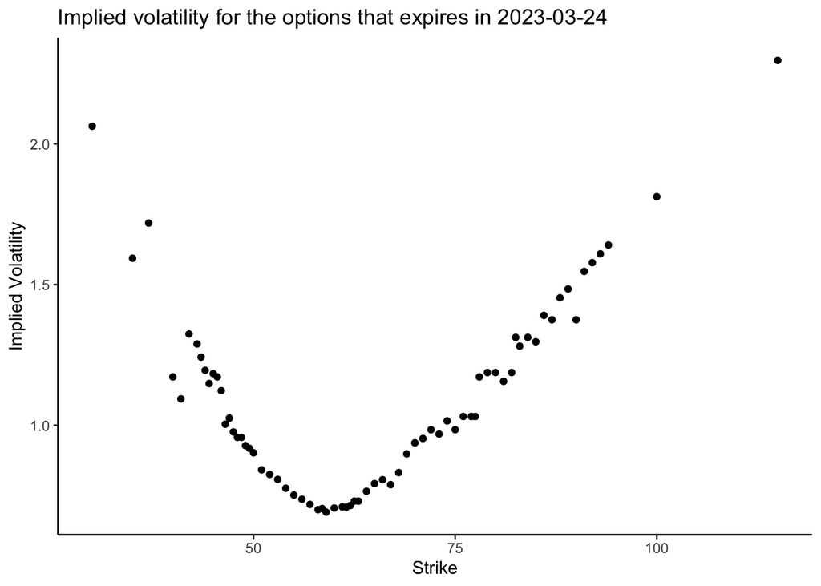

```r
price <- tail(Stock_price$value.SCHW.Close, 1)


# function for subset and plot
subset_n_plot <- function(sub_dados, date){
  object <- sub_dados %>% filter(Expiration == as.Date(date))
  ggplot(data = object, aes(x= Strike)) +
    geom_point(aes(y = IV)) +
    labs(x = "Strike", y = "Implied Volatility") +
    ggtitle(paste("Implied volatility for the options that expires in", date)) +
    theme_classic()
}


subset_n_plot(dados, "2023-03-24")# one day
```

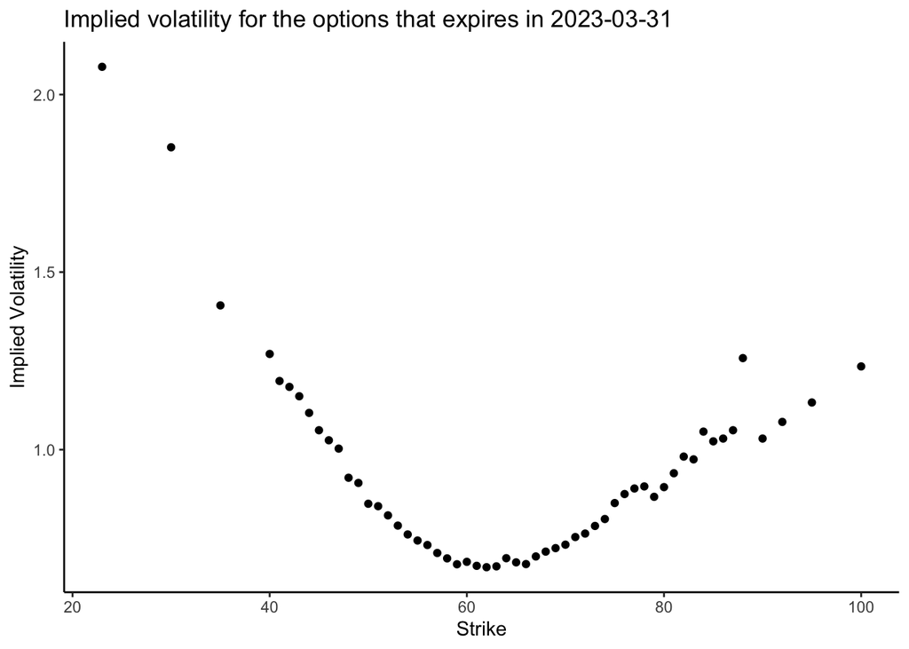

```r
subset_n_plot(dados, "2023-03-31")# one week
```

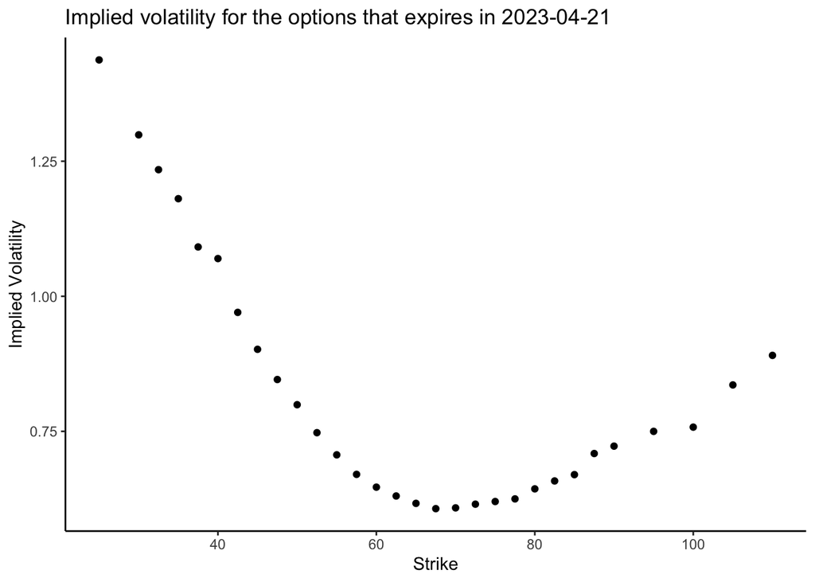

```r
subset_n_plot(dados, "2023-04-21")# one month
```

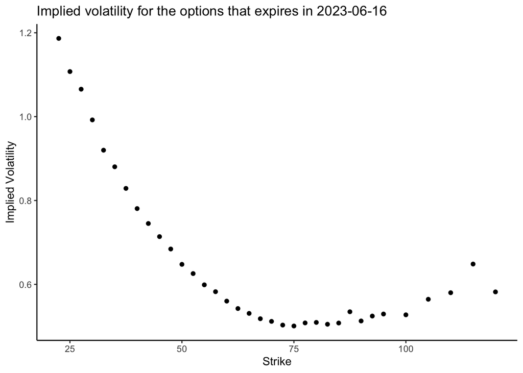

```r
subset_n_plot(dados, "2023-06-16")# three months
```

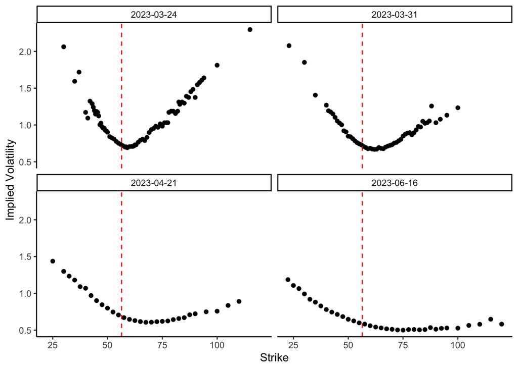

```r
# facet_wrap for plot different dates in the same plot

ggplot(data = dados, aes(x = Strike, y = IV)) +
  geom_point() +
  geom_vline(aes(xintercept = price), color = "red", linetype='dashed') +
  labs(x = "Strike", y = "Implied Volatility") +
  theme_classic() +
  facet_wrap(~ Expiration)
```

For the question 2b) to plot the volatility surface we used the python package for all maturities available on Yahoo Finance website

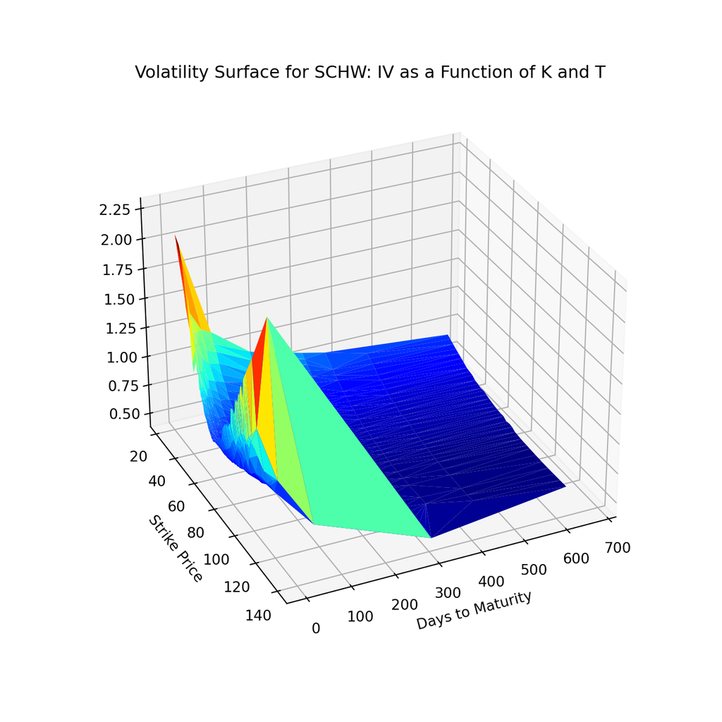

```python
# dependencies
import matplotlib.pyplot as plt
import yfinance as yf
import numpy as np
from mpl_toolkits import mplot3d
from datetime import datetime
from itertools import chain
from matplotlib import cm

# choose a ticker and get data via yahoofinance
ticker = "SCHW"
stock = yf.Ticker(ticker)
# store maturities
lMaturity = list(stock.options)

# get current date
today = datetime.now().date()
# empty list for days to expiration
lDTE = []
# empty list to store data for calls
lData_calls = []
# loop over maturities
for maturity in lMaturity:
    # maturity date
    maturity_date = datetime.strptime(maturity, '%Y-%m-%d').date()
    # DTE: difference between maturity date and today
    lDTE.append((maturity_date - today).days)
    # store call data
    lData_calls.append(stock.option_chain(maturity).calls)

# create empty lists to contain unlisted data
lStrike = []
lDTE_extended = []
lImpVol = []
for i in range(0,len(lData_calls)):
    # append strikes to list
    lStrike.append(lData_calls[i]["strike"])
    # repeat DTE so the list has same length as the other lists
    lDTE_extended.append(np.repeat(lDTE[i], len(lData_calls[i])))
    # append implied volatilities to list
    lImpVol.append(lData_calls[i]["impliedVolatility"])

# unlist list of lists
lStrike = list(chain(*lStrike))
lDTE_extended = list(chain(*lDTE_extended))
lImpVol = list(chain(*lImpVol))


# initiate figure
fig = plt.figure(figsize=(7,7))
# set projection to 3d
axs = plt.axes(projection="3d")
# use plot_trisurf from mplot3d to plot surface and cm for color scheme
axs.plot_trisurf(lDTE_extended, lStrike, lImpVol, cmap=cm.jet)
axs.invert_xaxis()

# change angle
axs.view_init(30, 65)
# add labels
plt.xlabel("Days to Maturity")
plt.ylabel("Strike Price")
plt.title(f"Volatility Surface for {ticker}: IV as a Function of K and T")
plt.show()
```

It’s possible to see that the implied volatility is higher for the call options with less than 200 days for maturity and strike between 100 and 40. The calls that are about to expire and are far from the current stock price of $56.4 (in this case In-the-Money or Out-the-Money) also consists in a region with high implied volatility.

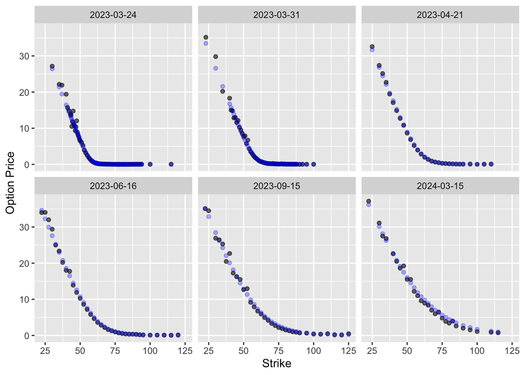

```r
#All possible dates
#dates <- c(2023-03-24, 2023-03-31, 2023-04-06, 2023-04-14, 2023-04-21, 2023-04-28, 2023-05-19, 2023-06-16, 2023-09-15, 2024-01-19, 2024-03-15, 2024-06-21, 2025-01-17)

dates <- c("2023-03-24", "2023-03-31", "2023-04-21", "2023-06-16", "2023-09-15", "2024-03-15")

dados <- get_datachain("SCHW", dates)


# defining the correct interest rates
i_1 <- as.numeric(tail(FFUD[2], 1))/100
i_2 <- as.numeric(tail(one_mon[2], 1))/100
i_3 <- as.numeric(tail(three_mon[2], 1))/100
i_4 <- as.numeric(tail(one_year[2], 1))/100


# Set the threshold dates
threshold_dates <- c(as.Date("2023-03-24"), as.Date("2023-03-31"), as.Date("2023-04-21"),
                     as.Date("2023-06-16"), as.Date("2023-09-15"), as.Date("2024-03-15"))

dados$i_rate <- 0
dados$i_rate <- case_when(
  dados$Expiration < threshold_dates[2] ~ i_1,
  dados$Expiration < threshold_dates[4] ~ i_2,
  dados$Expiration < threshold_dates[5] ~ i_3,
  TRUE ~ i_4
)


# Load option price and implied volatility data
options_data <- dados
options_data$S <- price
options_data$Maturity <- as.numeric(difftime(options_data$Expiration, Sys.Date(), units = "days"))

# Define Black-Scholes price function
bs_call <- function(S, K, T, r, sigma) {
  d1 <- (log(S/K) + (r + 0.5 * sigma^2) * T) / (sigma * sqrt(T))
  d2 <- d1 - sigma * sqrt(T)
  S * pnorm(d1) - K * exp(-r * T) * pnorm(d2)
}

# Calculate Black-Scholes prices for each option
options_data <- options_data %>%
  mutate(bs_price = bs_call(S, Strike, Maturity/365.25, r = i_rate, sigma = IV))

# Plot market and Black-Scholes prices
ggplot(options_data, aes(x = Strike, y = Last)) +
  geom_point(alpha= 0.6) +
  geom_point(aes(y = bs_price), color = "blue", alpha = 0.3) +
  labs(x = "Strike", y = "Option Price") +
  facet_wrap(~ Expiration)
```

To build this graph we estimated the price of a call option for the stock SCHW using the Black-Scholes model, the price of the call was the last one traded. The risk-free rate used was according to the maturity of the call, for calls with less than 1 month the risk-free was the FedFunds rate, for 1 month and less than 3 months the rate as the 1-month treasury rate, for calls with expiration date longer than 3 months and less than 1 year the 3-month treasury rate was used and for the other cases the 1-year treasury rate. According to the graph, it’s possible to see some changes between the estimated price with Black-Scholes and the last price traded for the call, interpreted as market price in this exercise, for options with expiration dates longer than 6 months.

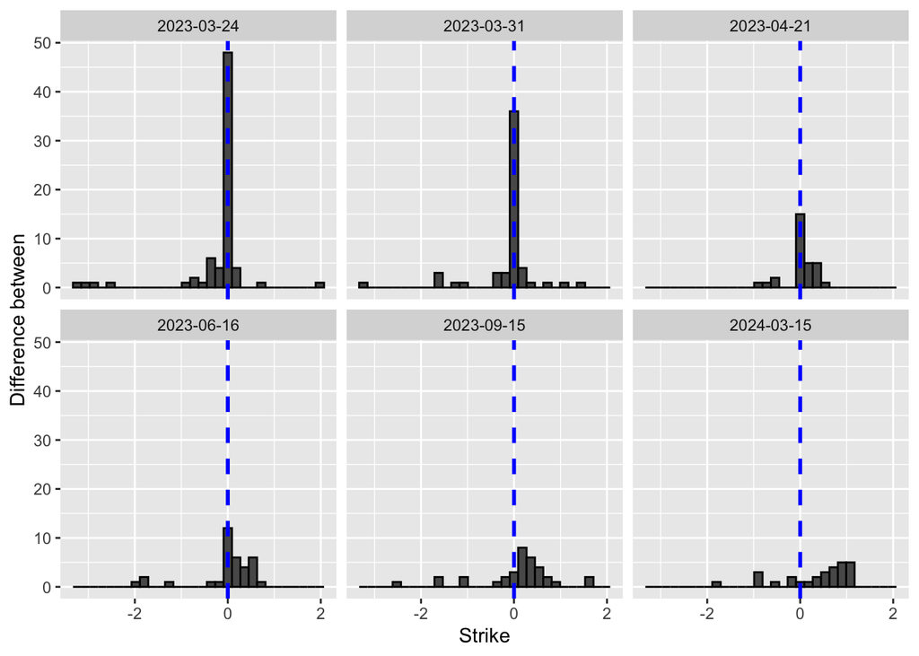

```r
options_data$diff <- options_data$bs_price - options_data$Last


# Plot market and Black-Scholes prices
ggplot(options_data, aes(x = diff)) +
  geom_histogram(color = "black") +
  geom_vline(aes(xintercept=0),
            color="blue", linetype="dashed", size=1)+
  labs(x = "Strike", y = "Difference between") +
  facet_wrap(~ Expiration)
```

Also it’s possible to see how the histogram of the difference between predicted price with Black-Scholes model and the market prices get far from zero as the time to maturity increases, supporting what we said before.